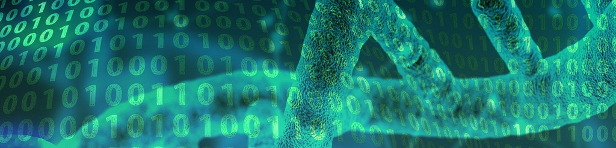

#### **Máster de Bioinformática y Bioestadística**

##### Análisis de datos ómicos: PEC 1

##### Dani Ibáñez 26-4-2021

### **DESCRIPCIÓN DEL ESTUDIO: Síndrome de Turner**

#### **Descripción general**

El síndrome de Turner és una patología descubierta por el propio endocrinólogo Henry Turner que afecta solo a mujeres y que se detecta, principalmente, por unos pliegues en el cuello en niñas pequeñas o recién nacidas y en un crecimiento que se para prematuramente quedando con estaturas claramente inferiores a la media. Esterilidad, extremidades hinchadas, genitales y mamas subdesarrolladas, son algunas otras características clínicas.

Aunque se describió esta patología en 1938, fue en 1959 cuando un grupo de científicos descubrieron la principal característica para su detección “sencilla”. Se trata de personas que solo tienen un cromosoma X completo, pudiendo tener parte del segundo o la mayoría con un solo cromosoma sexual X. Es por ello que se identifican como personas con 45 cromosomas (45X). Si el cromosoma X único o entero viene del padre hablaremos de genotipo o cariotipo 45Xp, y si procede de la madre hablaremos de genotipo o cariotipo 45Xm.

Parece demostrado que no es hereditario, pero a su vez se considera que la mayoría de incidencia es causada por el cromosoma X aportado por el padre, por lo que se considera que son patologías generadas o en el proceso de meiosis de los padres o en las primeras fases de multiplicación embrionaria. Esta segunda opción podría explicar por qué algunas mujeres presentan células con los dos cromosomas XX y otras células sin uno de ellos.

No hay un tratamiento específico definido, si bien, el principal problema que es la baja estatura responde a tratamientos de estimulación de hormona del crecimiento.

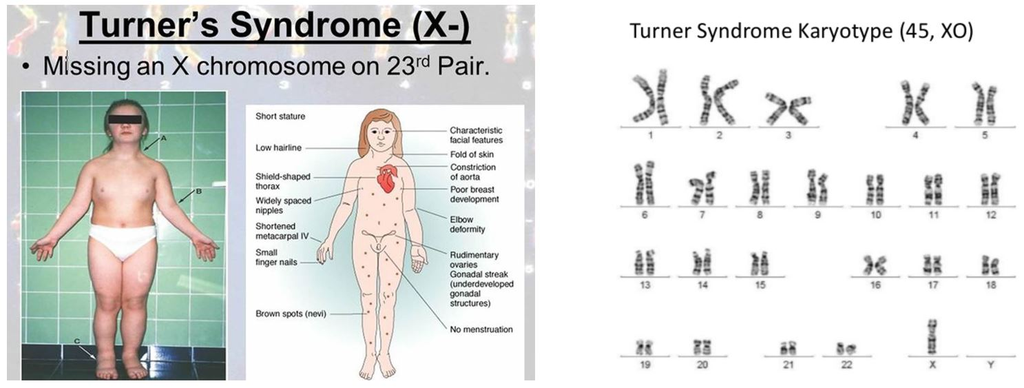

**Fuente: Página web healthjade.com**

#### **Descripción del estudio**

Al margen de los problemas de nacimiento, parece que existe predisposición de padecer enfermedades más graves como problemas cardiovasculares, diabetes o enfermedades de caracter autoinmune. Con este objetivo se realizan estudios de expresión génica comparando muestras de pacientes con esta patología.

En concreto, los científicos Cheng CM, Zhou J, Bondy C y otros, realizaron un análisis basado en 36 muestras distribuidas como sigue:

- 10 muestras de 10 mujeres con ambos cromosomas XX (“normales” 46,XX) que nos sirven de referencia.
- 16 muestras de 16 mujeres con un solo cromosoma X de procedencia materna 45,Xm
- 10 muestras de 10 mujeres con un solo cromosoma X de procedencia paterna 45,Xp

El experimento está realizado sobre microarray de affymetrix U133 versión 2.0 (GPL570) y se ha registrado en GEO con el repositorio GSE46687

Como ampliación de la información, el probe set U133 2.0 contiene un catálogo ampliado respecto la primera versión de U133. En este caso hablamos de 47.000 tránscritos distintos que se corresponden con 38.500 genes.

#### **Subset de 18 muestras para el estudio**

Para realizar el ejercicio de la PEC1, se ha extraído un subset de la muestra total de 36. En concreto se va a trabajar con una selección aleatoria de 6 muestras de cada uno de los 3 tipos, es decir 18 muestras, 6 XX (mujeres con los dos cromosomas X), 6 Xm (mujeres con un único cromosoma de origen materno) y 6 Xp (6 mujeres con un único cromosoma de origen paterno). Como se indica más abajo esta subselección aleatoria se ha realizado en base al número IDP de la UOC del alumno, en mi caso **IDP: 1083627**

#### **Documentación**

Para realizar el estudio he utilizado como guía la seguida por el Sr. Alex Sánchez en el estudio del caso GSE100924:

https://aspteaching.github.io/Omics_Data_Analysis-Case_Study_1-Microarrays/Case_Study_1-Microarrays_Analysis.html

Al final del documento se citan otras referencias usadas.

En el presente documento HTML no aparece el código, que sí se adjunta como archivo **rmd** aparte. El código incluye código de debug que se ha anulado con el caracter # pero se ha mantendo para que puedan comprobarse algunos pasos realizados.

### **PREPARACIÓN DEL ENTORNO DE TRABAJO**

#### **Carga de paquetes Bioconductor**

Para empezar vamos a instalar todos los paquetes necesarios para el estudio. La mayoría tienen relación con Biocondutor. Uno de los que tenemos que instalar es el feature data del microarray del estudio, en este caso el U133 plus 2. En concreto el paquete se llama **“hgu133plus2.db”**. Toda esta información se puede obtener de la página web de BIOCONDUCTOR:

https://bioconductor.org/packages/release/data/annotation/html/hgu133plus2.db.html

NOTA: Debo confesar que me volví loco con el paquete **org.Hs.eg.db** pues pensaba que el paquete **org.Mm.eg.db** era genérico de la anotación de genes de las principales especies hasta que me di cuenta que las letras Mm significaban Mus musculus y por lo tanto que había que optar por Hs Homo sapiens para cargar y trabajar con este estudio

#### **Creación del espacio de trabajo**

La gran cantidad de información nos “obliga” a estructurar la información en directorios. podemos seguir el convenio habitual en crear un directorio **data** y un directorio **results**. Además el proceso de workflow generará otros directorios que iremos viendo. Yo además he creado un directorio adicional que se llama **images**.

#### **Repositorio de github**

Toda la ejecución de la PEC1 la he ido actualizando en un repositorio de github al que se puede acceder si se desea clonar todo mi trabajo:

https://github.com/dibanezmal/OMICAS-MICROARRAY-PEC1

#### **Subset de muestras**

Tal como he informado antes, para este estudio se nos indica trabajar con un subset de las 36 muestras originales. En concreto nos piden aplicar la función del enunciado usando nuestro número IDP.

En mi caso, con **IDP: 1083627**, las muestras seleccionadas son las siguientes:

```
 [1]  1  2  3  8  9 10 11 13 17 18 23 25 27 28 29 30 33 35
```

A partir de aquí establecemos nuestro set de muestras personalizado con las 18 columnas concretas obtenidas. He cambiado el nombre de la columna de muestra **“sample_id”** y la del grupo diferencial va a ser **“karyotype”**.

Comprobamos cuales son y presentamos la tabla de los valores del dataframe llamado **targets18**:

##### **Tabla targets 18 de muestras seleccionadas para la PEC1 para IDP:1083627**

|  | sample_id | karyotype |
| --- | --- | --- |
| GSM1134016 | XX_rep1 | 46XX |
| GSM1134017 | XX_rep2 | 46XX |
| GSM1134018 | XX_rep3 | 46XX |
| GSM1134023 | XX_rep8 | 46XX |
| GSM1134024 | XX_rep9 | 46XX |
| GSM1134025 | XX_rep10 | 46XX |
| GSM1134026 | Xm_rep1 | 45Xm |
| GSM1134028 | Xm_rep3 | 45Xm |
| GSM1134032 | Xm_rep7 | 45Xm |
| GSM1134033 | Xm_rep8 | 45Xm |
| GSM1134038 | Xm_rep13 | 45Xm |
| GSM1134040 | Xm_rep15 | 45Xm |
| GSM1134042 | Xp_rep1 | 45Xp |
| GSM1134043 | Xp_rep2 | 45Xp |
| GSM1134044 | Xp_rep3 | 45Xp |
| GSM1134045 | Xp_rep4 | 45Xp |
| GSM1134048 | Xp_rep7 | 45Xp |
| GSM1134050 | Xp_rep9 | 45Xp |

### **CARGA DE DATOS DEL ESTUDIO Y PRIMERAS REFLEXIONES**

#### **Lectura de los 18 archivos CEL y carga de datos en la variable rawData**

A partir del repositorio GSE en la página web de OMNIBUS:

https://www.ncbi.nlm.nih.gov/geo/query/acc.cgi?acc=gse46687

Hemos descargado manualmente todos los archivos CEL y he dejado en el disco solo los correspondientes a las 18 muestras seleccionadas. Este proceso lo he realizado manualmente.

Por otra parte he creado manualmente un archivo llamado **targets18.csv** que contiene solo los registros de las 18 muestras seleccionadas. Los campos de este archivo vienen separados por coma.

Una vez eliminados los 18 sobrantes, hemos descomprimido los archivos y ahora ya estamos en disposición de leerlos mediante las funciones **list.celfiles** , **read.AnnotatedDataFrame()** y **read.celfiles()**

Para ello cargamos las librerías **oligo** y **Biobase** y creamos dos variables esenciales a partir de este instante:

- **my.targets** es el archivo de las 18 muestras.Le vamos a cambiar los nombres de las variables colnames()
- **rawData** es el DataFrame en que hemos cargado los datos en bruto procedentes de los archivos CEL.

```
An object of class 'AnnotatedDataFrame'
  rowNames: "GSM1134016" "GSM1134017" ... "GSM1134050" (18 total)
  varLabels: X.title. X.karyotype.
  varMetadata: labelDescription
```

```
variables de my.targets:  X.title. X.karyotype.
```

```
variables modificadas de my.targets:  sample_id karyotype
```

```
Reading in : ./data/GSM1134016_EA04058_25073_H133+_F15.CEL
Reading in : ./data/GSM1134017_EA04058_25074_H133+_F16.CEL
Reading in : ./data/GSM1134018_EA04058_25075_H133+_F20.CEL
Reading in : ./data/GSM1134023_EA04058_25080_H133+_F43.CEL
Reading in : ./data/GSM1134024_EA04058_25081_H133+_F45.CEL
Reading in : ./data/GSM1134025_EA04058_25082_H133+_F52.CEL
Reading in : ./data/GSM1134026_EA04058_28124_H133+_TS208.CEL
Reading in : ./data/GSM1134028_EA04058_30434_H133+_TS258.CEL
Reading in : ./data/GSM1134032_EA04058_52892_H133+_TS279.CEL
Reading in : ./data/GSM1134033_EA04058_52893_H133+_TS236.CEL
Reading in : ./data/GSM1134038_EA04058_52899_H133+_TS221.CEL
Reading in : ./data/GSM1134040_EA04058_53538_H133+_TS290.CEL
Reading in : ./data/GSM1134042_EA04058_30426_H133+_TS168.CEL
Reading in : ./data/GSM1134043_EA04058_30427_H133+_TS79.CEL
Reading in : ./data/GSM1134044_EA04058_52884_H133+_TS11.CEL
Reading in : ./data/GSM1134045_EA04058_52885_H133+_TS120.CEL
Reading in : ./data/GSM1134048_EA04058_52888_H133+_TS241.CEL
Reading in : ./data/GSM1134050_EA04058_52891_H133+_TS315.CEL
```

```
Comprobamos Clase rawData:  ExpressionFeatureSet
```

```
Comprobamos las dimensiones de los datos en rawData
```

```
[1] 1354896      18
```

```
Comprobamos las primeras filas del rawData
```

```
   "XX_rep1" "XX_rep2" "XX_rep3" "XX_rep8" "XX_rep9" "XX_rep10"
1         88       116       133       158       124        154
2       9954      7769      9658     10767      8026      11039
3        175       173       190       183       187        215
4      11354      8560     10681     10738     10564      11440
5        160       119       172       125       124        110
6        100       106       105       110       129        100
7      10122      8012     10307     10197      8770      11206
8        124       121       111       124       124        137
9       9548      7146      9474     10298      8291      10924
10       132       118       111       117       149        136
```

```
Comprobamos las últimas filas del rawData
```

```
        "Xp_rep1" "Xp_rep2" "Xp_rep3" "Xp_rep4" "Xp_rep7" "Xp_rep9"
1354887      3344      4620     11475     13856     12625     13246
1354888        84        61       279       391       346       378
1354889      3537      4611     11276     14069     13674     13187
1354890        59        74       260       405       391       385
1354891      3567      5098     11603     14664     14518     13363
1354892        58        55       256       266       305       312
1354893      3475      4702     11238     14918     13888     13579
1354894        90        69       334       355       347       525
1354895      3475      4583     11075     13999     13537     13241
1354896        63        67       279       296       372       387
```

#### **Número de registros, valores y primeras interpretaciones**

Como observaciones a los datos del rawData comentamos los siguientes puntos:

- Estamos ante una matriz de casi **millón y medio** de registros. Está claro que son datos en bruto, pues no tenemos millón y medio de tránscritos.
- Nos hemos fijado en que la serie muestra un dato alto y otro bajo de forma sucesiva. Creemos que eso se debe a la **técnica del mismatch**, es decir, la técnica que ofrece en la lectura, una sonda que encaja con el tránscrito y otra donde se ha modificado el nucleótido central no encajando en este segundo caso. Por lo tanto es lógico que tengamos un valor de expresión alto y otro bajo.
- Hemos modificado los nombres de las columnas ya que nos añade una x. un poco engorrosa.

Una vez hemos realizado la primera mirada sobre los datos en bruto, pasamos a plantear el estudio y a realizarlo.

### **PLANTEAMIENTO INICIAL DEL ESTUDIO Y PRIMERAS REFLEXIONES**

#### **Ampliando la información mediante getGEO()**

El archivo **targetsAll** que se nos ha proporcionado es muy escueto y no sé seguro si hay información adicional en el repositorio de Omnibus que nos ayude a realizar el estudio. Para ello buscaré en el **PhenoData** del repositorio GSE46687.

Presentamos las primeras muestras y los primeros campos de PhenoData:

```
                            title geo_accession                status
GSM1134016  46XX, biological rep1    GSM1134016 Public on Mar 01 2014
GSM1134017  46XX, biological rep2    GSM1134017 Public on Mar 01 2014
GSM1134018  46XX, biological rep3    GSM1134018 Public on Mar 01 2014
GSM1134019  46XX, biological rep4    GSM1134019 Public on Mar 01 2014
GSM1134020  46XX, biological rep5    GSM1134020 Public on Mar 01 2014
GSM1134021  46XX, biological rep6    GSM1134021 Public on Mar 01 2014
GSM1134022  46XX, biological rep7    GSM1134022 Public on Mar 01 2014
GSM1134023  46XX, biological rep8    GSM1134023 Public on Mar 01 2014
GSM1134024  46XX, biological rep9    GSM1134024 Public on Mar 01 2014
GSM1134025 46XX, biological rep10    GSM1134025 Public on Mar 01 2014
           submission_date last_update_date
GSM1134016     May 07 2013      Mar 01 2014
GSM1134017     May 07 2013      Mar 01 2014
GSM1134018     May 07 2013      Mar 01 2014
GSM1134019     May 07 2013      Mar 01 2014
GSM1134020     May 07 2013      Mar 01 2014
GSM1134021     May 07 2013      Mar 01 2014
GSM1134022     May 07 2013      Mar 01 2014
GSM1134023     May 07 2013      Mar 01 2014
GSM1134024     May 07 2013      Mar 01 2014
GSM1134025     May 07 2013      Mar 01 2014
```

He indicado unas primeras líneas para comprobar el contenido pero visualmente he podido confirmar que el **repositorio GSE46687 no aporta información adicional**. Absolutamente todos los campos son iguales en todas las muestras excepto los que ya aparecen en el archivo targetsAll.csv. Todo son mujeres (campo gender) como es lógico y las fechas que aparecen todas son iguales.

Por lo tanto el estudio, a mi entender, solo se puede basar en el campo que indica las diferencias en los cromosomas, definido en el archivo targetsAll como campo **karyotype**. Por lo tanto tenemos **un factor** con **3 levels**.

**IMPORTANTE: Comentar que lo normal para cualquier científico sería tener el estudio planteado al inicio de todo pero en este caso yo no lo he planteado hasta saber qué datos tengo disponibles. Por eso me lo planteo a partir de ahora.**

#### **Definición del estudio**

Una vez sabemos todos los datos que tenemos sobre las muestras, lo que queremos saber es cual es la expresión génica de las distintas muestras en función de su Cariotipo. A priori tenemos 3 grupos, XX, Xm y Xp. También lo podemos llamar 1 factor de 3 niveles.

A partir de aquí queremos analizar si hay diferencias entre la expresión en función del origen paterno o materno del cromosoma X heredado **Xp versus Xm**.

Por otra parte puede ser interesante investigar ver las diferencias entre las muestras **Xp** respecto las normales **XX** y las diferencias entre las muestras **Xm** y las normales **XX**

REFLEXION: Hay una reflexión que me hago y es que en los estudios y ejemplos realizados hasta el momento en los foros de la asignatura, los factores a analizar, los grupos, no tenían nada que ver con el propio genoma. El género, la temperatura, un tratamiento… Aquí me queda una duda que entiendo que es dificil de resolver por su sentido biológico y es que **como se puede analizar la expresión génica cuando los grupos de estudio dependen de tener o no el cromosoma X?** Cómo se puede analizar la expresión génica de todos los tránscritos del cromosoma X si te falta un cromosoma X? Tiene sentido incluir el cromosoma X en el estudio de expresión génica? La expresión de los tránscritos del cromosoma X de personas con síndrome de Turner aparecerán con la mitad de expresión que los normales, ya por defecto por solo tener uno? No sé, son cuestiones que creo que no las puede contestar un bioinformático no biólogo, pero que si que veo que pueden existir dudas en cuanto a cantidad de expresión.

También quiero comentar que a partir de aquí me han surgido un montón de preguntas biológicas sobre si la expresión de un grupo de tránscritos vienen determinados por los dos pares de cromosomas (paterno y materno), si proceden de muchas células o de pocas, si el tejido o la muestra ya está extraída del cuerpo, queda claro que tendremos adn, pero, ¿tenemos RNAm en células “muertas” cuando el RNAm es temporal? El ADN es fijo, pero el ARNm se crea y desaparece una vez se ha traducido a proteina. Bueno. comparto estas preguntas biológicas que quizá comparta en el foro posteriormente a la PEC.

### **CONTROL DE CALIDAD DE LOS DATOS EN BRUTO**

#### **Una primera mirada rápida a rawData con summary()**

Aunque los datos vienen de archivos CEL de un reprositorio publicado, he preferido dar una mirada directa a los datos mediante la función clásica **summary()** que nos permite ver que no hay datos NA, ni datos NULL y que los máximos, mínimos y medias se mueven todos entre márgenes razonables. De todos modos sorprenden la disparidad de medias en una tabla con casi millón y medio de resgistros.

```
   "XX_rep1"         "XX_rep2"       "XX_rep3"         "XX_rep8"
 Min.   :   36.0   Min.   :   41   Min.   :   34.0   Min.   :   38.0
 1st Qu.:   66.0   1st Qu.:   80   1st Qu.:   67.0   1st Qu.:   70.0
 Median :   87.0   Median :  111   Median :   89.0   Median :   92.0
 Mean   :  223.5   Mean   :  247   Mean   :  225.3   Mean   :  241.8
 3rd Qu.:  142.0   3rd Qu.:  184   3rd Qu.:  149.0   3rd Qu.:  152.0
 Max.   :65513.0   Max.   :61573   Max.   :65527.0   Max.   :65525.0
   "XX_rep9"         "XX_rep10"        "Xm_rep1"         "Xm_rep3"
 Min.   :   44.0   Min.   :   34.0   Min.   :   33.0   Min.   :   30.0
 1st Qu.:   92.0   1st Qu.:   61.0   1st Qu.:   64.0   1st Qu.:   51.0
 Median :  123.0   Median :   81.0   Median :   80.0   Median :   67.0
 Mean   :  258.8   Mean   :  207.1   Mean   :  172.2   Mean   :  152.7
 3rd Qu.:  194.0   3rd Qu.:  134.0   3rd Qu.:  122.0   3rd Qu.:  110.0
 Max.   :34083.0   Max.   :46316.0   Max.   :37440.0   Max.   :40033.0
   "Xm_rep7"       "Xm_rep8"         "Xm_rep13"        "Xm_rep15"
 Min.   :   75   Min.   :   58.0   Min.   :   48.0   Min.   :   44.0
 1st Qu.:  197   1st Qu.:  158.0   1st Qu.:  117.0   1st Qu.:  112.0
 Median :  272   Median :  224.0   Median :  167.0   Median :  160.0
 Mean   :  609   Mean   :  608.8   Mean   :  452.9   Mean   :  417.8
 3rd Qu.:  448   3rd Qu.:  405.0   3rd Qu.:  298.0   3rd Qu.:  279.0
 Max.   :64340   Max.   :65533.0   Max.   :53180.0   Max.   :64784.0
   "Xp_rep1"         "Xp_rep2"         "Xp_rep3"         "Xp_rep4"
 Min.   :   31.0   Min.   :   28.0   Min.   :   53.0   Min.   :   33.0
 1st Qu.:   57.0   1st Qu.:   50.0   1st Qu.:  143.0   1st Qu.:  156.0
 Median :   74.0   Median :   69.0   Median :  196.0   Median :  231.0
 Mean   :  161.6   Mean   :  160.7   Mean   :  516.6   Mean   :  697.7
 3rd Qu.:  122.0   3rd Qu.:  115.0   3rd Qu.:  348.0   3rd Qu.:  449.0
 Max.   :65533.0   Max.   :63971.0   Max.   :64493.0   Max.   :65534.0
   "Xp_rep7"         "Xp_rep9"
 Min.   :   26.0   Min.   :   61.0
 1st Qu.:  126.0   1st Qu.:  152.0
 Median :  180.0   Median :  220.0
 Mean   :  511.7   Mean   :  577.9
 3rd Qu.:  339.0   3rd Qu.:  404.0
 Max.   :65533.0   Max.   :65522.0
```

#### **Analisis de rwaData mediante función ArrayQualityMetrics()**

El titular se podría considerar un oximoron. Analizar la calidad de unos datos que no están revisados ni normalizados no tiene gran utilidad, a menos que nos sirva para ver el efecto de las funciones entre el antes y el después.

Esta función **arrayQualityMetrics** nos crea un directorio con todos los datos del análisis que se pueden leer lanzando el archivo **index.html** del directorio. Adjuntamos el resultado de la tabla resumen sobre rawData:

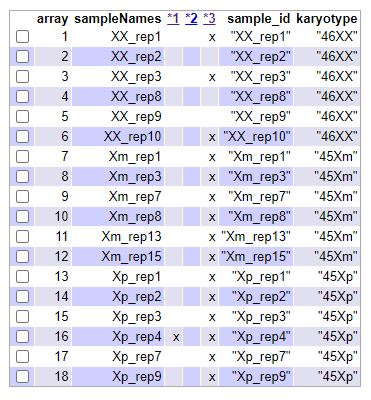

En cualquier caso, como hemos dicho, todos estos datos son en bruto y **no deberíamos hacerles mucho caso** hasta que los tengamos normalizados.

### **NORMALIZACIÓN**

#### **Normalización de los datos mediante función rma() y supervisión**

Vamos a llamar **eset_rma** al expresionSet de los datos normalizados. El proceso de normalización yo pensaba inicialmente que solo actuaba en detectar las desviaciones técnicas de las lecturas pero he aprendido realizando la PEC que la normalización realiza un trabajo de lectura de los datos en bruto para convertir los **1.354.896 registros** de las lecturas del analizador, en unos números de expresión de cada uno de los **54.675 tránscritos (y controles)** como seguidamente veremos. Comentar que los 54.675 registros deben tener elementos de control porque en el datasheet del GPL570 se habla de 47.000 tránscritos. Por lo tanto hay otros registros complementarios que no son estrictamente tránscritos.

Vamos a comprobar con una serie de lecturas qué tenemos en el nuevo **expresionSet normalizado eset_rma** y vamos a ver que los datos ya tienen un aspecto completamente distinto.

```
Background correcting
Normalizing
Calculating Expression
```

```
Comprobamos las dimensiones de los datos en eset_rma
```

```
[1] 54675    18
```

```
Comprobamos las primeras filas del eset_rma
```

```
          "XX_rep1" "XX_rep2" "XX_rep3" "XX_rep8" "XX_rep9" "XX_rep10"
1007_s_at  7.207656  6.905313  6.574902  6.650012  6.661997   6.961066
1053_at    7.256191  7.079954  7.253400  7.344920  6.990913   6.496573
117_at     8.753912  8.159330  8.571536  7.731424  8.608466   8.506030
121_at     7.674366  8.105192  7.688936  7.681396  7.535204   7.437984
1255_g_at  3.551687  3.515149  3.452685  3.315840  3.437913   3.408560
1294_at    9.554406  9.279305  9.215286  9.242828  9.347073   9.795328
1316_at    4.947334  5.042483  4.952601  4.912385  5.264421   5.913237
1320_at    3.955525  4.141353  4.210289  3.903351  4.527909   4.070071
1405_i_at 11.358375 11.031041  9.974503 11.709484 11.315969  10.954654
1431_at    4.146239  4.128431  3.855348  3.694543  4.175387   3.794452
```

```
Comprobamos las últimas filas del eset_tma
```

```
                     "Xp_rep2" "Xp_rep3" "Xp_rep4" "Xp_rep7" "Xp_rep9"
AFFX-r2-Ec-bioD-3_at 13.322765 12.334653 11.781256 12.578372 12.212060
AFFX-r2-Ec-bioD-5_at 12.812320 11.837246 11.092396 11.875327 11.640353
AFFX-r2-P1-cre-3_at  14.273867 13.899404 13.512300 13.960116 13.788210
AFFX-r2-P1-cre-5_at  14.227520 13.656078 13.218077 13.777802 13.551672
AFFX-ThrX-3_at        3.926658  4.180027  4.299661  3.826693  4.036082
AFFX-ThrX-5_at        3.799589  3.780552  3.994661  3.830306  3.997531
AFFX-ThrX-M_at        3.595493  3.571914  3.737425  3.535151  3.479586
AFFX-TrpnX-3_at       3.344018  3.434676  3.496964  3.498203  3.486672
AFFX-TrpnX-5_at       3.928664  3.597579  3.936992  3.733449  3.947139
AFFX-TrpnX-M_at       3.649991  3.694574  3.555250  3.382724  3.760172
```

#### **Una mirada rápida sobre eset_rma con summary()**

De nuevo realizamos una mirada con summary(). Aunque los datos viene de archivos CEL de un reprositorio publicado, he preferido dar una mirada directa a los datos mediante la función clásica **summary()** que nos permite ver que no hay datos NA, ni datos NULL y que los máximos, mínimos y medias se mueven todos entre márgenes razonables.

```
   "XX_rep1"        "XX_rep2"        "XX_rep3"        "XX_rep8"
 Min.   : 2.826   Min.   : 2.835   Min.   : 2.922   Min.   : 2.879
 1st Qu.: 4.058   1st Qu.: 4.161   1st Qu.: 4.076   1st Qu.: 4.065
 Median : 5.313   Median : 5.368   Median : 5.327   Median : 5.314
 Mean   : 5.909   Mean   : 5.906   Mean   : 5.914   Mean   : 5.907
 3rd Qu.: 7.453   3rd Qu.: 7.294   3rd Qu.: 7.430   3rd Qu.: 7.425
 Max.   :14.896   Max.   :14.907   Max.   :14.999   Max.   :14.932
   "XX_rep9"        "XX_rep10"       "Xm_rep1"        "Xm_rep3"
 Min.   : 2.898   Min.   : 2.728   Min.   : 2.797   Min.   : 2.794
 1st Qu.: 4.173   1st Qu.: 4.088   1st Qu.: 4.077   1st Qu.: 4.093
 Median : 5.444   Median : 5.336   Median : 5.320   Median : 5.320
 Mean   : 5.964   Mean   : 5.909   Mean   : 5.917   Mean   : 5.905
 3rd Qu.: 7.429   3rd Qu.: 7.438   3rd Qu.: 7.457   3rd Qu.: 7.407
 Max.   :15.046   Max.   :15.041   Max.   :15.017   Max.   :15.050
   "Xm_rep7"        "Xm_rep8"        "Xm_rep13"       "Xm_rep15"
 Min.   : 2.822   Min.   : 2.872   Min.   : 2.887   Min.   : 2.800
 1st Qu.: 4.175   1st Qu.: 4.142   1st Qu.: 4.109   1st Qu.: 4.123
 Median : 5.430   Median : 5.367   Median : 5.341   Median : 5.352
 Mean   : 5.925   Mean   : 5.912   Mean   : 5.901   Mean   : 5.910
 3rd Qu.: 7.332   3rd Qu.: 7.338   3rd Qu.: 7.365   3rd Qu.: 7.334
 Max.   :15.040   Max.   :15.009   Max.   :14.965   Max.   :14.978
   "Xp_rep1"        "Xp_rep2"        "Xp_rep3"        "Xp_rep4"
 Min.   : 2.856   Min.   : 2.921   Min.   : 2.803   Min.   : 2.876
 1st Qu.: 4.098   1st Qu.: 4.133   1st Qu.: 4.092   1st Qu.: 4.111
 Median : 5.347   Median : 5.362   Median : 5.347   Median : 5.355
 Mean   : 5.910   Mean   : 5.898   Mean   : 5.921   Mean   : 5.909
 3rd Qu.: 7.405   3rd Qu.: 7.320   3rd Qu.: 7.459   3rd Qu.: 7.382
 Max.   :15.054   Max.   :15.013   Max.   :15.052   Max.   :14.905
   "Xp_rep7"        "Xp_rep9"
 Min.   : 2.902   Min.   : 2.865
 1st Qu.: 4.119   1st Qu.: 4.100
 Median : 5.355   Median : 5.349
 Mean   : 5.915   Mean   : 5.899
 3rd Qu.: 7.404   3rd Qu.: 7.388
 Max.   :15.053   Max.   :15.009
```

#### **Comprobación del proceso de normalización con Boxplot**

Una buena manera de comprobar el trabajo de la función rma() es comprobar el efecto que se produce en los datos de las muestras mediante boxplot, **antes y después de la normalización.**

Vamos a comparar los dos gráficos aunque la verdad, creo que estamos comparando peras con manzanas, de más de 1 millón de registros con datos de todo tipo (por ejemplo incluye los mismatch), a los 50 y pico mil que básicamente son datos ya reales de expresión génica. Como estamos en una PEC, vamos a realizar el ejercicio comparativo.

Para ello vamos a realizar un boxplot sobre el expressionSet **rawData** y posteriormente sobre **eset_rma**

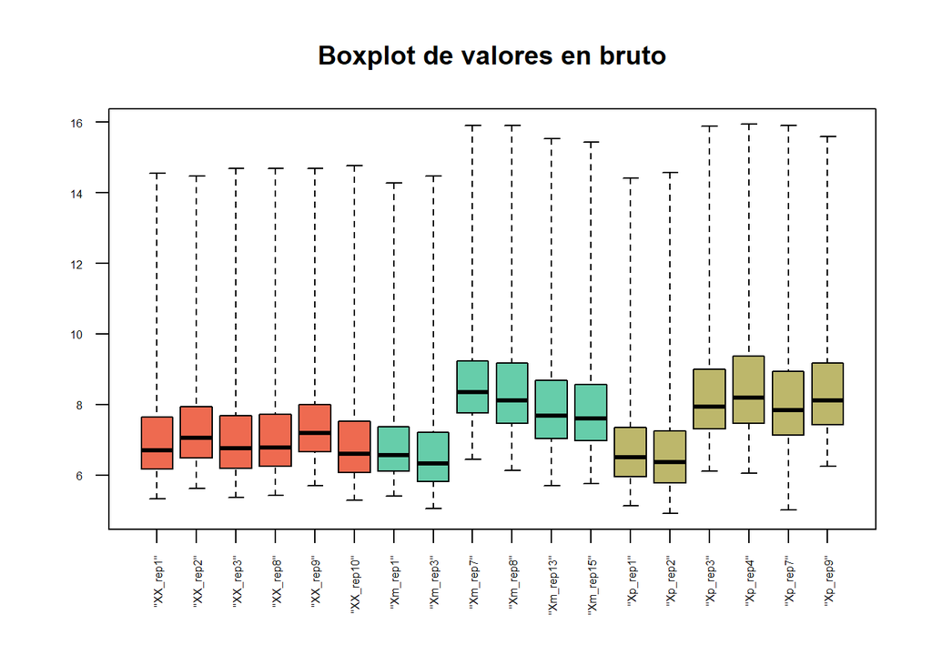

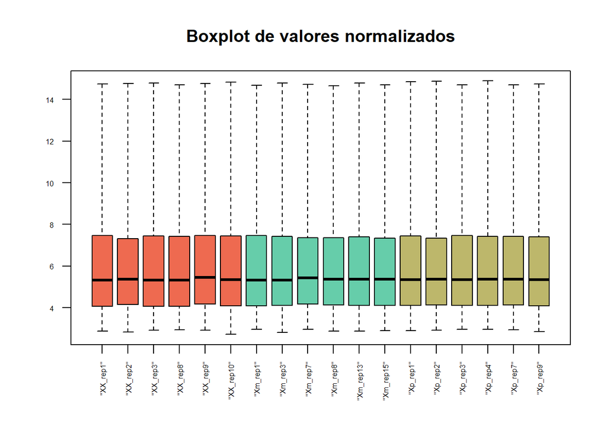

### **CONTROL DE CALIDAD SOBRE DATOS NORMALIZADOS**

#### **Control de calidad mediante ARRAYQUALITYMETRICS**

En esta ocasión podemos hacer más caso a la función ArrayQualityMetrics pero por ejemplo vemos que de los tres métodos de control solo el análisis de DistanceBetweenArrays nos da un **posible oulier** en la muestra etiquetada como **Xm_rep1**, la muestra con síndrome de Turner con cromosoma de origen materno 45Xm. En principio, a menos que aparezca algun otro dato que refuerce la anomalia, no le daremos mucha importancia. Adjuntamos el resultado de la tabla resumen sobre eset_rma:

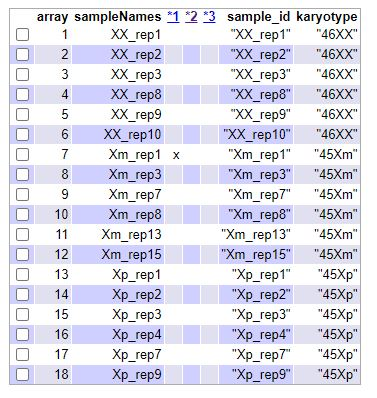

Vamos a seguir el estudio con otros gráficos a ver si obtenemos más claridad en lo que tenemos entre manos.

#### **Estudio de un posible efecto batch**

Por otra parte el grupo depende del Cariotipo que es un dato que no tiene posible error, no es numérico. O tienes 2 cromosomas XX o no los tienes. No hay temperaturas, no hay tratamientos.

#### **Control de calidad mediante gráficos de componentes PCA()**

El gráfico de datos normalizados nos permite ver una distribución de las muestras más o menos lógica:

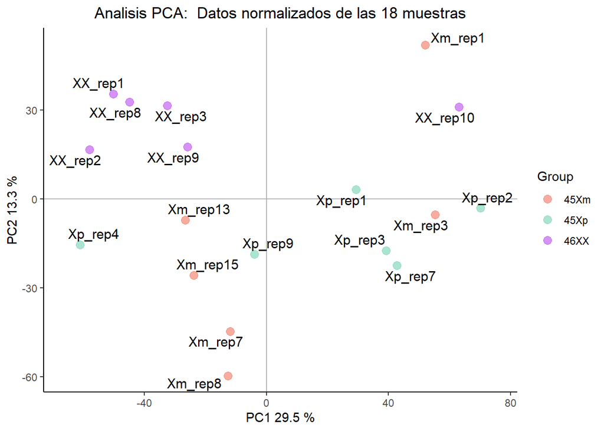

Si nos fijamos en el cuadro de componentes, vemos que, en esencia, todas las muestras con doble cromosoma XX aparecen en la parte superior del cuadro (variación según el componente PC2) mientras que las muestras con un solo cromosoma están en la parte inferior del cuadro. En cambio, la muestra detectada como outlier mediante ArrayQualityMetrics, **Xm_rep1** aparece arriba de todo, casi fuera del cuadro, en lo que parece una anomalía.

Al aparecer nuevamente esta muestra como posible outlier, me dispongo a realizar un **estudio provisional sin la muestra Xm_rep1** y comprobar el mismo gráfico PCA a ver si se notan los cambios.

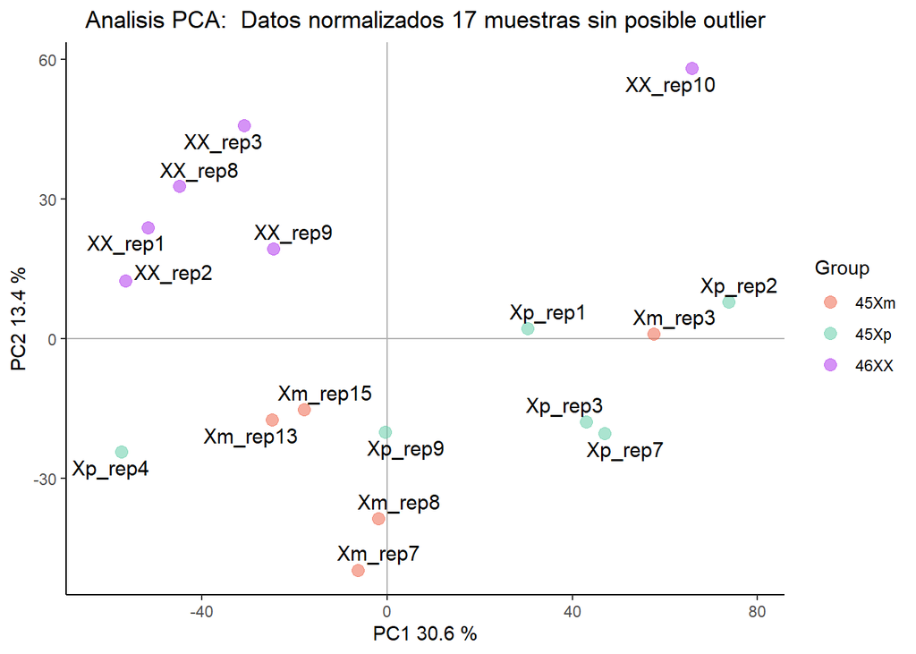

Aunque tenemos una muestra muy escorada en un extremo, esta vez **XX_rep10**, el cuadro parece más coherente, sobretodo respecto el componente PC2. También se aprecia una tendencia a disponer muestras Xp o Xm en función del componente PC1, a lado y lado del eje vertical, aunque hay muestras que rompen claramente esa distribución.

### **ANALISIS CON DATOS NORMALIZADOS Y REDUCIDOS A 17 MUESTRAS**

#### **Inicio del estudio con subset de 17 muestras sobre la variable eset_m17**

Aunque es una decisión que puede tener consecuencias en las conclusiones, decido eliminar la muestra identificada como outlier en ArrayQualityMetrics y corroborada en el gráfico pca.

A partir de aquí voy a montar el expressionset de 17 muestras y a realizar el estudio de expresión génica.

- targets17 <- pData(eset_rma)[-7,]
- exprs_m17 <- exprs(eset_rma)[,-7]
- FenoData <- new(“AnnotatedDataFrame”, data=targets17)
- eset_m17 <- ExpressionSet(assayData = exprs_m17, phenoData=FenoData) #montamos en nuevo expresionsSET

A partir de ahora mis datos están en el expressionSet **eset_m17** Hacemos una previsualización para comprobar que lo hemos realizado correctamente:

PhenoData del subset de las 17 muestras

|  | sample_id | karyotype |
| --- | --- | --- |
| “XX_rep1” | “XX_rep1” | “46XX” |
| “XX_rep2” | “XX_rep2” | “46XX” |
| “XX_rep3” | “XX_rep3” | “46XX” |
| “XX_rep8” | “XX_rep8” | “46XX” |
| “XX_rep9” | “XX_rep9” | “46XX” |
| “XX_rep10” | “XX_rep10” | “46XX” |
| “Xm_rep3” | “Xm_rep3” | “45Xm” |
| “Xm_rep7” | “Xm_rep7” | “45Xm” |
| “Xm_rep8” | “Xm_rep8” | “45Xm” |
| “Xm_rep13” | “Xm_rep13” | “45Xm” |
| “Xm_rep15” | “Xm_rep15” | “45Xm” |
| “Xp_rep1” | “Xp_rep1” | “45Xp” |
| “Xp_rep2” | “Xp_rep2” | “45Xp” |
| “Xp_rep3” | “Xp_rep3” | “45Xp” |
| “Xp_rep4” | “Xp_rep4” | “45Xp” |
| “Xp_rep7” | “Xp_rep7” | “45Xp” |
| “Xp_rep9” | “Xp_rep9” | “45Xp” |

```
          "XX_rep1" "XX_rep2" "XX_rep3" "XX_rep8" "XX_rep9"
1007_s_at  7.207656  6.905313  6.574902  6.650012  6.661997
1053_at    7.256191  7.079954  7.253400  7.344920  6.990913
117_at     8.753912  8.159330  8.571536  7.731424  8.608466
121_at     7.674366  8.105192  7.688936  7.681396  7.535204
1255_g_at  3.551687  3.515149  3.452685  3.315840  3.437913
1294_at    9.554406  9.279305  9.215286  9.242828  9.347073
1316_at    4.947334  5.042483  4.952601  4.912385  5.264421
1320_at    3.955525  4.141353  4.210289  3.903351  4.527909
1405_i_at 11.358375 11.031041  9.974503 11.709484 11.315969
1431_at    4.146239  4.128431  3.855348  3.694543  4.175387
```

#### **Visualización de porcentaje de genes expresados**

Podemos observar qué porcentage de genes se expresan por encima del umbral del 95% y 99%. La inmensa mayoría de los genes claramente expresados representan menos del 1% del total. De todos modos necesitamos referencias en la banda baja para tener expresión relativa.

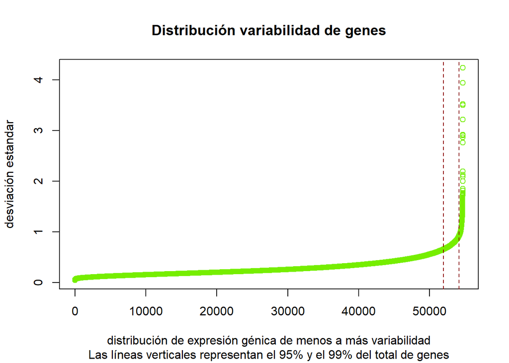

#### **Filtrado de los probes sin valores representativos de expresión**

Podemos hacer algunas pruebas variando el porcentaje de genes que se expresan de forma clara, 99%, 95%. En concreto, para seguir el estudio, nos quedaremos con un **filtrado del 80%**:

```
Si aplicamos un filtro del 99% de genes, nos quedan  202  probesets
```

```
Si aplicamos un filtro del 95% de genes, nos quedan  1008  probesets
```

```
$numDupsRemoved
[1] 21734

$numLowVar
[1] 16129

$numRemoved.ENTREZID
[1] 12770

$feature.exclude
[1] 10
```

```
[1] 4032   17
```

```
Si aplicamos un filtro del 80% de genes, nos quedan  4032  probesets
```

En nuestro caso nos quedaremos con un subset de probes correspondiente al **20%** de “genes” expresados. Pongo “genes” entrecomillados porque he estado usando este termino con abuso de lenguaje, ya que son tránscritos de RNAm que combinan distintos exones del mismo gen. Por lo tanto hemos eliminado provisionalmente el 80% de los probesets aparentemente “sin valor” en el estudio.

#### **Guardado de archivos en disco**

En esta ocasión vamos a guardar en disco tanto los archivos relacionados con el **eset_rma** como con el **eset_m17** siguiendo la guia de Alex Sánchez, como he comentado.

### **MATRICES COMPARATIVAS ENTRE LOS 3 GRUPOS**

#### **Matriz de contrastes**

En este apartado vamos a construir la matriz de contrastes. En nuestro caso vamos a estudiar dos comparaciones concretas:

```
           XX Xp Xm
"XX_rep1"   0  0  1
"XX_rep2"   0  0  1
"XX_rep3"   0  0  1
"XX_rep8"   0  0  1
"XX_rep9"   0  0  1
"XX_rep10"  0  0  1
"Xm_rep3"   1  0  0
"Xm_rep7"   1  0  0
"Xm_rep8"   1  0  0
"Xm_rep13"  1  0  0
"Xm_rep15"  1  0  0
"Xp_rep1"   0  1  0
"Xp_rep2"   0  1  0
"Xp_rep3"   0  1  0
"Xp_rep4"   0  1  0
"Xp_rep7"   0  1  0
"Xp_rep9"   0  1  0
attr(,"assign")
[1] 1 1 1
attr(,"contrasts")
attr(,"contrasts")$karyotype
[1] "contr.treatment"
```

```
      Contrasts
Levels Xp_vs_Xm Xm_vs_XX
    XX        0       -1
    Xp        1        0
    Xm       -1        1
```

#### **Representación de genes mayormente expresados mediante Volcanoplot()**

Vamos a realizar un análisis de genes diferencialmente expresados. En concreto vamos a destacar **los 6 más destacados** de cada comparación mediante **Volcanoplot()**.

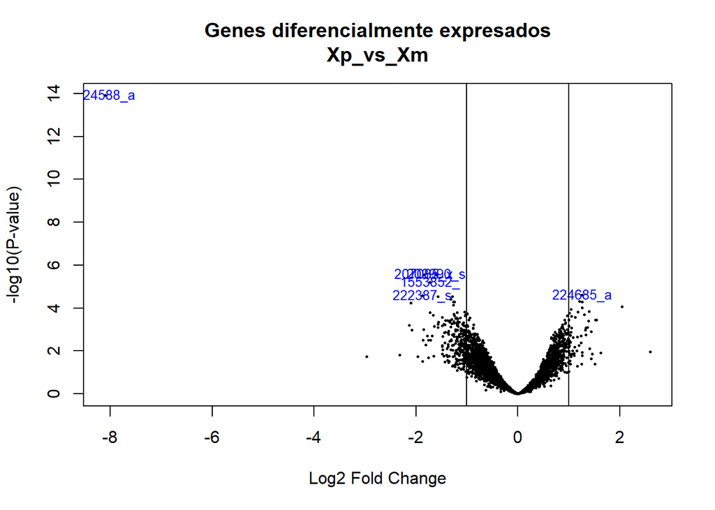

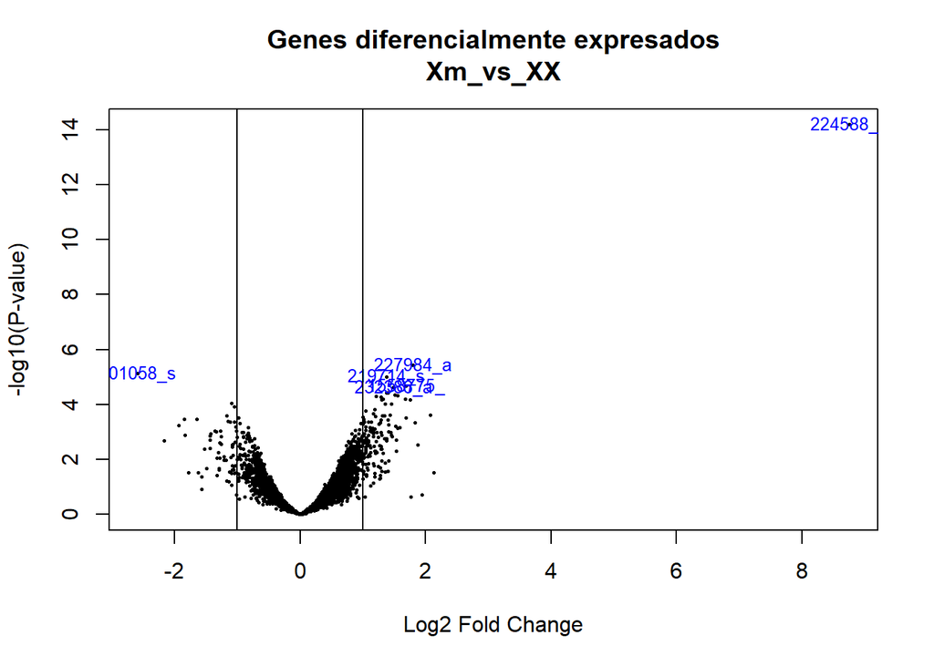

Analizando los resultados, los dos gráficos Volcanplot, nos sorprende ver que hay un transcrito 224588_at que provoca un desplazamiento de todo el mapa de expresión.

Investigamos un poco y vemos que este tránscrito es del tipo XIST (X Inactive Specific Transcript). Se puede consultar en esta página web:

https://genecards.weizmann.ac.il/cgi-bin/geneannot/GA_search.pl?keyword_type=probe_set_id&array=HG-U133&target=genecards&keyword=224588_at

Al tratarse de un transcrito inactivo, me inclino a pensar que hay algun tipo de anomalía y decido apartarlo y ver qué apariencia tienen los mismos gráficos sin dicho probeset. Creamos el nuevo expressionSet sin el probe set **224588_at**. Visualizo los datos de la posición y de las dimensiones del nuevo probeset:

#### **Creando un nuevo subset eset_reduced sin probeset 224588_a**

```
[1] 4032   17
```

```
[1] 3139
```

```
[1] "224588_at"
```

```
[1] 4031   17
```

#### **Genes diferencialmente expresados en nuevos gráficos Volcano()**

En efecto, si comprobamos los nuevos gráficos, nos dan unos resultados mucho más coherentes. en este caso hemos optado por indicar los genes mediante sus nombres o símbolos:

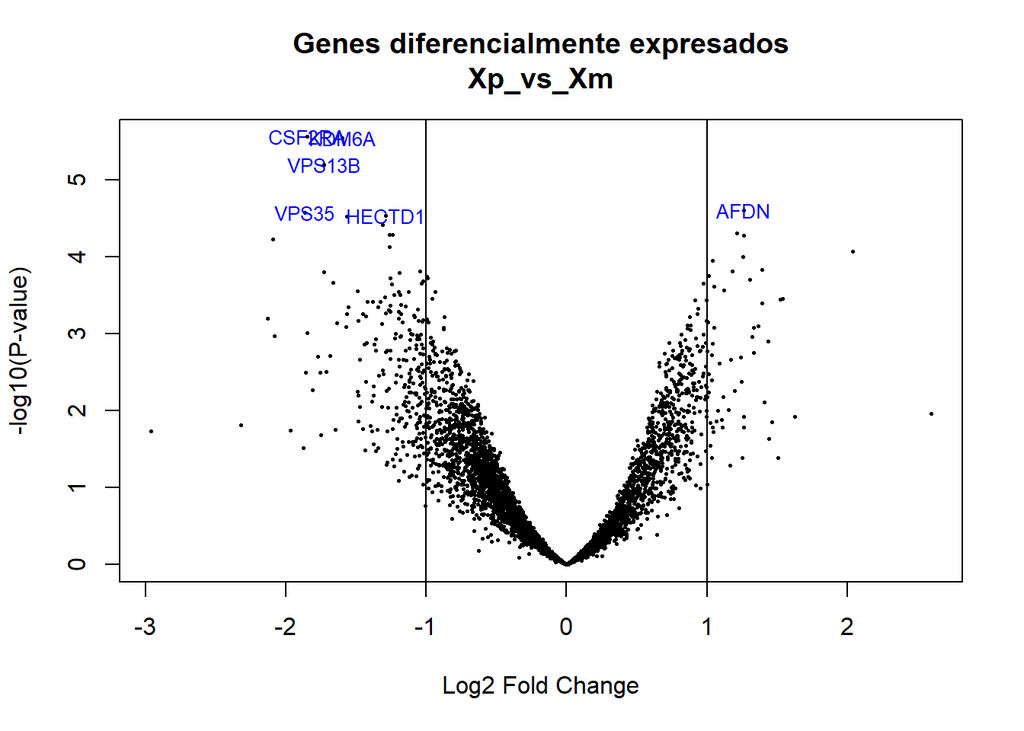

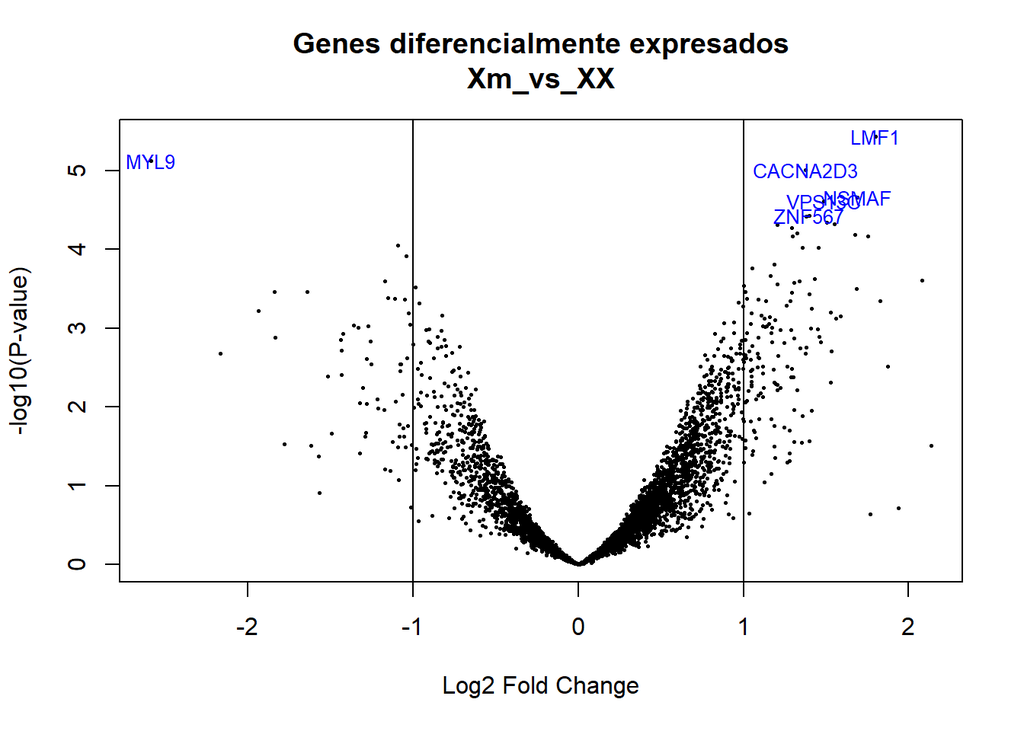

#### **Diagrama de venn de relaciones entre comparaciones**

Para cuantificar unas relaciones y otras podemos realizar un diagrama de Venn de relaciones:

```
       Xp_vs_Xm Xm_vs_XX
Down        181       29
NotSig     3803     3906
Up           47       96
```

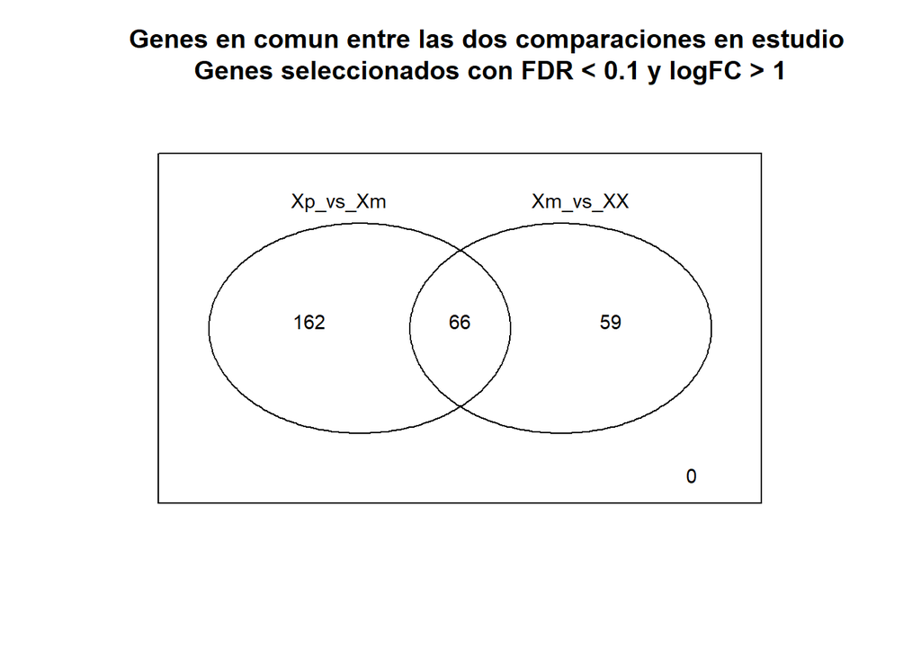

#### **Mapas amplios de expresión génica mediante heatmap()**

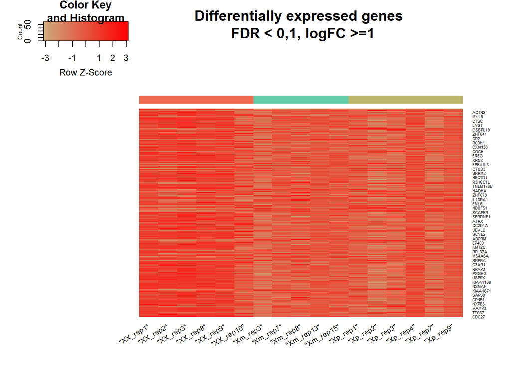

#### **Listas de genes diferencialmente expresados()**

Construcción de tablas de genes diferencialmente expresados clasificados de menor a mayor p_valor, es decir de mayor expresión a menor. Esto se realiza con la función del paquete limma **topTable()**

```
                 logFC  AveExpr         t      P.Value   adj.P.Val        B
207085_x_at  -1.849201 7.669037 -6.216802 2.732106e-06 0.005657252 4.666118
203990_s_at  -1.598213 6.098201 -6.205226 2.806873e-06 0.005657252 4.641998
1553852_at   -1.728616 5.704916 -5.860218 6.319863e-06 0.008491790 3.914601
224685_at     1.260529 6.919490  5.290428 2.479129e-05 0.017213321 2.680919
222387_s_at  -1.867595 8.445389 -5.261721 2.657843e-05 0.017213321 2.617847
1557100_s_at -1.290304 6.579894 -5.222579 2.922759e-05 0.017213321 2.531723
```

```
                 logFC  AveExpr         t      P.Value  adj.P.Val        B
227984_at     1.801778 6.682336  6.086164 3.708651e-06 0.01321663 4.396057
201058_s_at  -2.588452 8.346349 -5.791743 7.435838e-06 0.01321663 3.770954
219714_s_at   1.373573 8.306174  5.674404 9.836240e-06 0.01321663 3.518740
1558775_s_at  1.686833 6.015776  5.347970 2.156686e-05 0.01841531 2.808766
232386_at     1.487684 6.994386  5.298862 2.428972e-05 0.01841531 2.700993
242429_at     1.396482 6.415410  5.122020 3.732677e-05 0.01841531 2.311049
```

#### **Anotación de genes diferencialmente expresados()**

Una vez ya tenemos las tablas de los genes que destacan por su expresión, de mayor a menor en ambas comparaciones necesitamos traducirlos a sus correspondientes nombres en función del microarray, en este caso **GPL570** con la información en el paquete **hgu133plus2.db**:

```
Comparación de genes grupo Xp respecto grupo Xm:
```

```
        PROBEID   SYMBOL  ENTREZID
1       1487_at    ESRRA      2101
2  1552275_s_at      PXK     54899
3  1552277_a_at  MSANTD3     91283
4  1552287_s_at  AFG3L1P       172
5    1552302_at TMEM106A    113277
6  1552309_a_at     NEXN     91624
7  1552312_a_at    MFAP3      4238
8    1552318_at   GIMAP1    170575
9    1552327_at   ARMCX4 100131755
10   1552334_at   TRIOBP     11078
                                               GENENAME      logFC  AveExpr
1                       estrogen related receptor alpha  0.5991362 8.202485
2     PX domain containing serine/threonine kinase like -1.1987518 7.352565
3              Myb/SANT DNA binding domain containing 3  0.1158419 6.583558
```

[output cut: 18 more lines]

```
Comparación de genes grupo Xm respecto grupo XX:
```

```
        PROBEID   SYMBOL  ENTREZID
1       1487_at    ESRRA      2101
2  1552275_s_at      PXK     54899
3  1552277_a_at  MSANTD3     91283
4  1552287_s_at  AFG3L1P       172
5    1552302_at TMEM106A    113277
6  1552309_a_at     NEXN     91624
7  1552312_a_at    MFAP3      4238
8    1552318_at   GIMAP1    170575
9    1552327_at   ARMCX4 100131755
10   1552334_at   TRIOBP     11078
                                               GENENAME       logFC  AveExpr
1                       estrogen related receptor alpha -0.45313745 8.202485
2     PX domain containing serine/threonine kinase like  0.90985958 7.352565
3              Myb/SANT DNA binding domain containing 3 -0.46675534 6.583558
```

[output cut: 18 more lines]

Hemos querido comprobar que salieran bien los dos objetos de anotación de las dos comparaciones.

### **SIGNIFICADO BIOLOGICO DE LOS RESULTADOS DEL ESTUDIO**

#### **Análisis de enriquecimento mediante enrichPathway del paquete ReactomePA**

Vamos a analizar de las tabals de genes más expresados en ambas comparaciones, cuales pueden corresponder a algun tipo de significado de función biológica. En este sentido enecsitamos filtrar la parte más expresada de la tabla según un corte que podemos establecer en base al p.Valor ajustado mediante método de reducción de falsos positivos de Benjamini y Hochberg (1995).

De este modo la función de listado de genes se fija mediante un filtro de **adj.P.Val <0.20**.

También se requieren los identificadores de Entrez Gene para todos los genes analizados. Para ello se emplean todos los genes disponibles (aunque es una discusión a parte si emplear estos, o los de la TopTable), y se define nuestra base como todos los genes que tienen al menos una anotación en Gene Ontology. Se usa el paquete **org.Hs.egGO.db**.

```
Xp_vs_Xm Xm_vs_XX
    1487      510
```

```
Total de genes mapeados:  20730
```

```
[1] "Xp_vs_Xm" "Xm_vs_XX"
```

```
Comparación:  Xp_vs_Xm
                         ID
R-HSA-6798695 R-HSA-6798695
R-HSA-983695   R-HSA-983695
R-HSA-983169   R-HSA-983169
R-HSA-983705   R-HSA-983705
R-HSA-140534   R-HSA-140534
R-HSA-210990   R-HSA-210990
                                                                                     Description
R-HSA-6798695                                                           Neutrophil degranulation
R-HSA-983695  Antigen activates B Cell Receptor (BCR) leading to generation of second messengers
R-HSA-983169                              Class I MHC mediated antigen processing & presentation
R-HSA-983705                                              Signaling by the B Cell Receptor (BCR)
R-HSA-140534                    Caspase activation via Death Receptors in the presence of ligand
R-HSA-210990                                                                 PECAM1 interactions
              GeneRatio   BgRatio       pvalue     p.adjust       qvalue
R-HSA-6798695    79/891 477/10668 1.786117e-09 2.277299e-06 2.053094e-06
R-HSA-983695     12/891  32/10668 5.019779e-06 3.200109e-03 2.885052e-03
R-HSA-983169     52/891 368/10668 1.098780e-04 3.894243e-02 3.510847e-02
R-HSA-983705     22/891 112/10668 1.221723e-04 3.894243e-02 3.510847e-02
R-HSA-140534      7/891  16/10668 1.616766e-04 4.078563e-02 3.677020e-02
R-HSA-210990      6/891  12/10668 1.986904e-04 4.078563e-02 3.677020e-02
                                                                                                                                                                                                                                                                                                            …
R-HSA-6798695 IQGAP1/CLEC5A/SCAMP1/ATP8B4/CPNE1/FCGR2A/CYBA/ATP11B/CAND1/C…
R-HSA-983695                                                                                                                                                                                                                                                                                                …
R-HSA-983169                                                                                                                                                                            HECTD1/CDC27/ZNRF1/UBE2O/TPP2/VAMP3/CYBA/RNF19A/TLR1/KLHL20/…
R-HSA-983705                                                                                                                                                                                                                                                                                                …
R-HSA-140534                                                                                                                                                                                                                                                                                                …
R-HSA-210990                                                                                                                                                                                                                                                                                                …
              Count
R-HSA-6798695    79
R-HSA-983695     12
R-HSA-983169     52
R-HSA-983705     22
R-HSA-140534      7
R-HSA-210990      6

Comparación:  Xm_vs_XX
                         ID                                    Description
R-HSA-6802952 R-HSA-6802952              Signaling by BRAF and RAF fusions
```

[output cut: 11 more lines]

```
R-HSA-6802957     9/308  84/10668 0.0006823376 0.06418978 0.06163315
                                                                        geneID
R-HSA-6802952               ITGA2B/ITGB3/FXR1/CLCN6/IQGAP1/TLN1/TRAK1/HRAS/VWF
R-HSA-430116                                               FLNA/GP9/PIK3R1/VWF
R-HSA-114608  FLNA/ITGA2B/PHACTR2/ITGB3/CLU/TLN1/PF4/ALDOA/EGF/SPARC/F13A1/VWF
R-HSA-76005   FLNA/ITGA2B/PHACTR2/ITGB3/CLU/TLN1/PF4/ALDOA/EGF/SPARC/F13A1/VWF
R-HSA-6802948                                ITGA2B/ITGB3/IQGAP1/TLN1/HRAS/VWF
R-HSA-6802957               ITGA2B/ITGB3/FXR1/CLCN6/IQGAP1/TLN1/TRAK1/HRAS/VWF
              Count
R-HSA-6802952     9
R-HSA-430116      4
R-HSA-114608     12
R-HSA-76005      12
R-HSA-6802948     6
R-HSA-6802957     9
```

#### **Enrichement de la comparación Xp vs Xm**

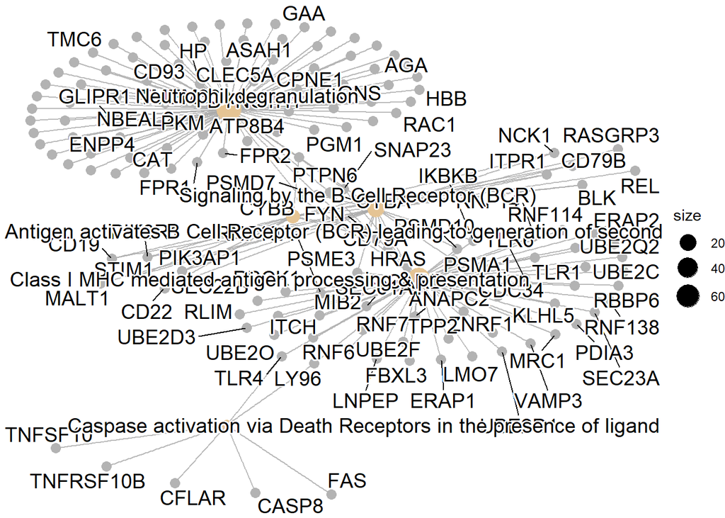

#### **Enrichement de la comparación Xm vs XX**

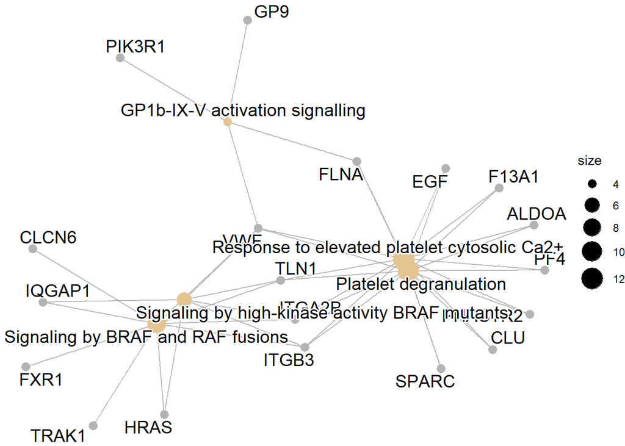

Primeras filas de comparación Xm vs XX

|  | Description | GeneRatio | BgRatio | pvalue | p.adjust |
| --- | --- | --- | --- | --- | --- |
| R-HSA-6802952 | Signaling by BRAF and RAF fusions | 9/308 | 67/10668 | 0.000121633706018215 | 0.0641897800462147 |
| R-HSA-430116 | GP1b-IX-V activation signalling | 4/308 | 12/10668 | 0.000280757960578162 | 0.0641897800462147 |
| R-HSA-114608 | Platelet degranulation | 12/308 | 129/10668 | 0.000346041823974655 | 0.0641897800462147 |
| R-HSA-76005 | Response to elevated platelet cytosolic Ca2+ | 12/308 | 134/10668 | 0.000490296457178142 | 0.0641897800462147 |

Primeras filas de comparación Xp vs Xm

|  | Description | GeneRatio | BgRatio | pvalue | p.adjust |
| --- | --- | --- | --- | --- | --- |
| R-HSA-6798695 | Neutrophil degranulation | 79/891 | 477/10668 | 1.78611669145953e-09 | 2.2772987816109e-06 |
| R-HSA-983695 | Antigen activates B Cell Receptor (BCR) leading to generation of second messengers | 12/891 | 32/10668 | 5.01977907906982e-06 | 0.00320010916290701 |
| R-HSA-983169 | Class I MHC mediated antigen processing & presentation | 52/891 | 368/10668 | 0.000109878043935686 | 0.038942431410041 |
| R-HSA-983705 | Signaling by the B Cell Receptor (BCR) | 22/891 | 112/10668 | 0.000122172333835423 | 0.038942431410041 |

### **RESUMEN DE RESULTADOS**

Todos los resultados se encuentran en los archivos siguientes:

Lista de archivos generados en el análisis

| Lista de ficheros: |
| --- |
| data4Heatmap.csv |
| normalized.Data.csv |
| normalized.Data.Rda |
| normalized.Filtered.Data.csv |
| normalized17.Data.csv |
| normalized17.Data.Rda |
| ReactomePA.Results.Xm_vs_XX.csv |
| ReactomePA.Results.Xp_vs_Xm.csv |
| ReactomePABarplot.Xm_vs_XX.pdf |
| ReactomePABarplot.Xp_vs_Xm.pdf |
| ReactomePAcnetplot.Xm_vs_XX.pdf |
| ReactomePAcnetplot.Xp_vs_Xm.pdf |
| topAnnotated_Xm_vs_XX.csv |
| topAnnotated_Xp_vs_Xm.csv |

### **FUENTES DE INFORMACION**

https://es.wikipedia.org/wiki/S%C3%ADndrome_de_Turner

https://www.ncbi.nlm.nih.gov/geo/query/acc.cgi?acc=gse46687

https://www.affymetrix.com/support/technical/datasheets/human_datasheet.pdf

https://aspteaching.github.io/Omics_Data_Analysis-Case_Study_1-Microarrays/Case_Study_1-Microarrays_Analysis.html

file:///C:/Users/PENYA1994/Downloads/Bioinformatic_Analysis_Identifies_Potential_Key_Ge.pdf

https://pubmed.ncbi.nlm.nih.gov/22946286/

https://rpubs.com/Cristina_Gil/PCA

https://bioconductor.org/packages/devel/workflows/vignettes/maEndToEnd/inst/doc/MA-Workflow.html

https://www.bioconductor.org/packages/devel/bioc/vignettes/limma/inst/doc/usersguide.pdf

https://guangchuangyu.github.io/2014/11/proper-use-of-gosemsim/

https://bioconductor.statistik.tu-dortmund.de/packages/3.8/bioc/vignettes/ReactomePA/inst/doc/ReactomePA.html

### **REPOSITORIO DE GITHUB**

Toda la ejecución de la PEC1 la he ido actualizando en un repositorio de github al que se puede acceder si se desea clonar todo mi trabajo:

https://github.com/dibanezmal/OMICAS-MICROARRAY-PEC1